# food-consumption

## Inspired by Julia Silge

This time round, we want to predict which countries are Asian countries, based on their patterns of food consumption in the eleven categories from [food consumption and CO2 emissions.](https://github.com/rfordatascience/tidytuesday/blob/master/data/2020/2020-02-18/readme.md)

```r
food_consumption <- readr::read_csv('https://raw.githubusercontent.com/rfordatascience/tidytuesday/master/data/2020/2020-02-18/food_consumption.csv')
food_consumption
```

```
## # A tibble: 1,430 x 4
##    country   food_category            consumption co2_emmission
##    <chr>     <chr>                          <dbl>         <dbl>
##  1 Argentina Pork                           10.5          37.2
##  2 Argentina Poultry                        38.7          41.5
##  3 Argentina Beef                           55.5        1712
##  4 Argentina Lamb & Goat                     1.56         54.6
##  5 Argentina Fish                            4.36          6.96
##  6 Argentina Eggs                           11.4          10.5
##  7 Argentina Milk - inc. cheese            195.          278.
##  8 Argentina Wheat and Wheat Products      103.           19.7
##  9 Argentina Rice                            8.77         11.2
## 10 Argentina Soybeans                        0             0
## # … with 1,420 more rows
```

We have a long, tidy data which needs to be made wide for modeling. To identify the continent which each country resides in, we can use countrycode package. We will also create a new variable ‘asia’ for prediction that tells us whether a country is in Asia or not.

```r
library(janitor)
library(countrycode)
food <- food_consumption %>%
  select(-co2_emmission) %>%
  pivot_wider(names_from = food_category,
              values_from = consumption) %>%
  clean_names() %>%
  mutate(continent = countrycode(country,
                                 origin = "country.name",
                                 destination = "continent")) %>%
  mutate(asia = case_when(continent == "Asia" ~ "Asia",
                          TRUE ~ "Other")) %>%
  select(-country, -continent) %>%
  mutate_if(is.character, factor)
food
```

```
## # A tibble: 130 x 12
##     pork poultry  beef lamb_goat  fish  eggs milk_inc_cheese wheat_and_wheat…
##    <dbl>   <dbl> <dbl>     <dbl> <dbl> <dbl>           <dbl>            <dbl>
##  1  10.5    38.7  55.5      1.56  4.36 11.4             195.            103.
##  2  24.1    46.1  33.9      9.87 17.7   8.51            234.             70.5
##  3  10.9    13.2  22.5     15.3   3.85 12.5             304.            139.
##  4  21.7    26.9  13.4     21.1  74.4   8.24            226.             72.9
##  5  22.3    35.0  22.5     18.9  20.4   9.91            137.             76.9
##  6  27.6    50.0  36.2      0.43 12.4  14.6             255.             80.4
##  7  16.8    27.4  29.1      8.23  6.53 13.1             211.            109.
##  8  43.6    21.4  29.9      1.67 23.1  14.6             255.            103.
##  9  12.6    45    39.2      0.62 10.0   8.98            149.             53
## 10  10.4    18.4  23.4      9.56  5.21  8.29            288.             92.3
## # … with 120 more rows, and 4 more variables: rice <dbl>, soybeans <dbl>,
## #   nuts_inc_peanut_butter <dbl>, asia <fct>
```

We are left with quite a small dataset, but we will try to model this data to see how we can do hyperparameters tuning.

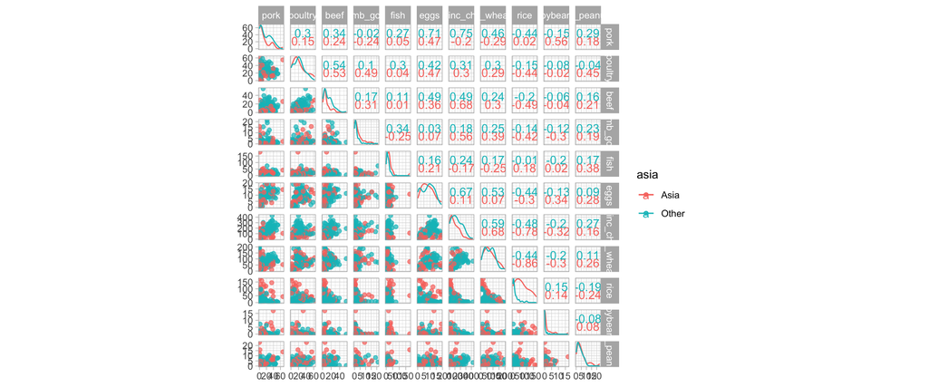

```r
library(GGally)
ggscatmat(food, columns = 1:11, color = "asia", alpha = 0.7)
```

Notice how important rice is! Also see how the relationships between different food categories is different for Asian and non-Asian countries; a tree-based model like a random forest is good as learning interactions like this.

## Hyperparameters tuning

- Create a set of bootstrap resamples to use for tuning
- Create a model specification for a random forest where we will tune mtry (# of predictors to sample at each split) and min_n (# of observations needed to keep splitting nodes).

```r
library(tidymodels)
set.seed(1234)
food_boot <- bootstraps(food, times = 30)
food_boot
```

```
## # Bootstrap sampling
## # A tibble: 30 x 2
##    splits           id
##    <list>           <chr>
##  1 <split [130/50]> Bootstrap01
##  2 <split [130/51]> Bootstrap02
##  3 <split [130/51]> Bootstrap03
##  4 <split [130/44]> Bootstrap04
##  5 <split [130/54]> Bootstrap05
##  6 <split [130/53]> Bootstrap06
##  7 <split [130/47]> Bootstrap07
##  8 <split [130/50]> Bootstrap08
##  9 <split [130/47]> Bootstrap09
## 10 <split [130/44]> Bootstrap10
## # … with 20 more rows
```

```r
rf_spec <- rand_forest(
  mode = "classification",
  mtry = tune(),
  trees = 1000,
  min_n = tune()) %>%
  set_engine("ranger")

rf_spec
```

```
## Random Forest Model Specification (classification)
##
## Main Arguments:
##   mtry = tune()
##   trees = 1000
##   min_n = tune()
##
## Computational engine: ranger
```

Here, we will use grid search to train many models. Furthermore, we can do parallel processing to speed up our training.

```r
doParallel::registerDoParallel()

rf_grid <- tune_grid(
  asia ~. ,
  model = rf_spec,
  resamples = food_boot)

rf_grid
```

```
## # Bootstrap sampling
## # A tibble: 30 x 4
##    splits           id          .metrics          .notes
##    <list>           <chr>       <list>            <list>
##  1 <split [130/50]> Bootstrap01 <tibble [20 × 5]> <tibble [0 × 1]>
##  2 <split [130/51]> Bootstrap02 <tibble [20 × 5]> <tibble [0 × 1]>
##  3 <split [130/51]> Bootstrap03 <tibble [20 × 5]> <tibble [0 × 1]>
##  4 <split [130/44]> Bootstrap04 <tibble [20 × 5]> <tibble [0 × 1]>
##  5 <split [130/54]> Bootstrap05 <tibble [20 × 5]> <tibble [0 × 1]>
##  6 <split [130/53]> Bootstrap06 <tibble [20 × 5]> <tibble [0 × 1]>
##  7 <split [130/47]> Bootstrap07 <tibble [20 × 5]> <tibble [0 × 1]>
##  8 <split [130/50]> Bootstrap08 <tibble [20 × 5]> <tibble [0 × 1]>
##  9 <split [130/47]> Bootstrap09 <tibble [20 × 5]> <tibble [0 × 1]>
## 10 <split [130/44]> Bootstrap10 <tibble [20 × 5]> <tibble [0 × 1]>
## # … with 20 more rows
```

We can check our results

```r
rf_grid %>%
  collect_metrics()
```

```
## # A tibble: 20 x 7
##     mtry min_n .metric  .estimator  mean     n std_err
##    <int> <int> <chr>    <chr>      <dbl> <int>   <dbl>
##  1     1    12 accuracy binary     0.797    30 0.0115
##  2     1    12 roc_auc  binary     0.828    30 0.0111
##  3     2    37 accuracy binary     0.808    30 0.0105
##  4     2    37 roc_auc  binary     0.821    30 0.0110
##  5     3    33 accuracy binary     0.817    30 0.0102
##  6     3    33 roc_auc  binary     0.823    30 0.0114
##  7     4    23 accuracy binary     0.823    30 0.0102
##  8     4    23 roc_auc  binary     0.830    30 0.0113
##  9     5     3 accuracy binary     0.832    30 0.0120
## 10     5     3 roc_auc  binary     0.837    30 0.0112
## 11     6    29 accuracy binary     0.819    30 0.0104
## 12     6    29 roc_auc  binary     0.825    30 0.0113
## 13     8     8 accuracy binary     0.818    30 0.0114
## 14     8     8 roc_auc  binary     0.828    30 0.0115
## 15     9    18 accuracy binary     0.816    30 0.0101
## 16     9    18 roc_auc  binary     0.826    30 0.0110
## 17    10    15 accuracy binary     0.812    30 0.00982
## 18    10    15 roc_auc  binary     0.826    30 0.0115
## 19    11    29 accuracy binary     0.806    30 0.00913
## 20    11    29 roc_auc  binary     0.821    30 0.0113
```

And to see which model performed best in terms of ‘accuracy’ or ‘roc_auc’.

```r
rf_grid %>%
  show_best("roc_auc")
```

```
## # A tibble: 5 x 7
##    mtry min_n .metric .estimator  mean     n std_err
##   <int> <int> <chr>   <chr>      <dbl> <int>   <dbl>
## 1     5     3 roc_auc binary     0.837    30  0.0112
## 2     4    23 roc_auc binary     0.830    30  0.0113
## 3     8     8 roc_auc binary     0.828    30  0.0115
## 4     1    12 roc_auc binary     0.828    30  0.0111
## 5     9    18 roc_auc binary     0.826    30  0.0110
```

```r
world <- map_data("world")

food_country <- food_consumption %>%
  left_join(world %>% mutate(country = region), by = 'country')
```

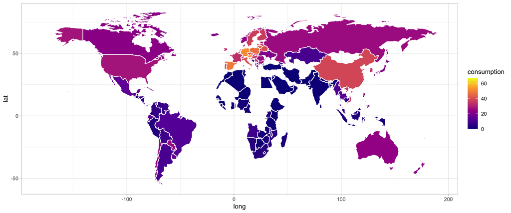

```r
food_country %>%
  filter(food_category == "Pork") %>%
  ggplot(aes(long, lat, group = group))+
  geom_polygon(aes(fill = consumption), color = "white")+
  scale_fill_viridis_c(option = "C")
```